# Lecture 17 - Multivariate STATS

Author

Bill Perry

# Introduction to Multivariate Statistics

## Overview

- Multivariate data: multiple variables per object
- Types of multivariate analyses
  - Functional vs. structural methods
  - R-mode vs. Q-mode analyses
- Eigenvectors, eigenvalues, and components
- Distance and dissimilarity measures
- Data transformations and standardization
- Screening multivariate data
- MANOVA

# Multivariate Data

- Multiple variables recorded about each object (individual, quadrat, site, etc.)
- Objects: rows (i = 1 to n)
- Variables: columns (j = 1 to p)
- Examples:
  - Stream sites with multiple chemical parameters
  - Species with multiple morphological traits
  - Sample units with multiple species abundances

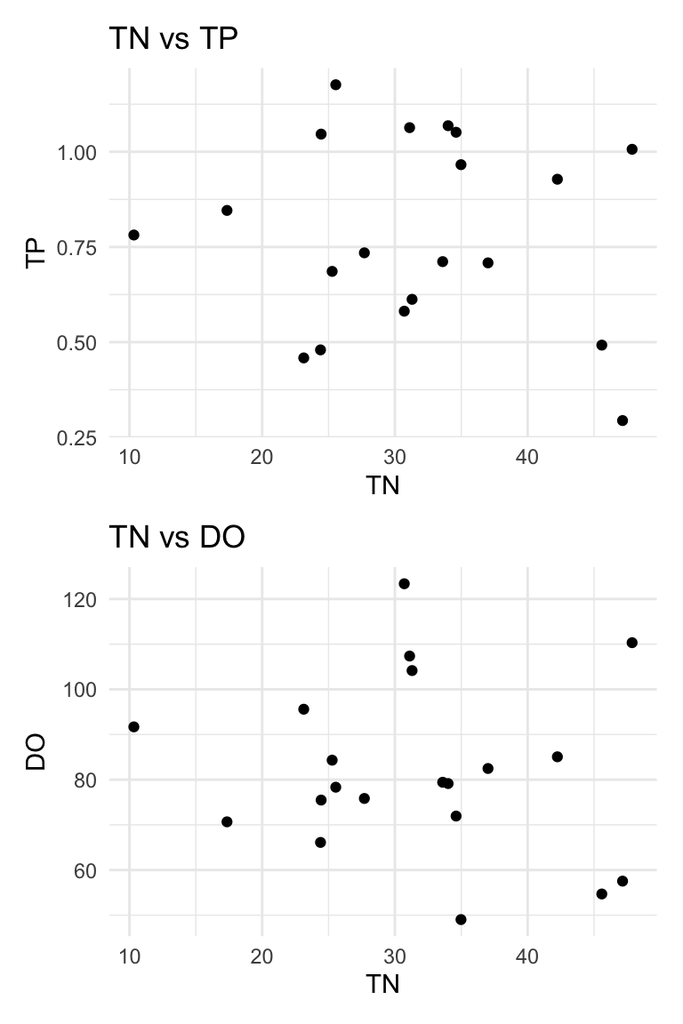

**Multivariate data vs. multivariate analysis**

We’ve already seen multivariate data in multiple regression and multi-factor ANOVA, but now we’ll look at cases with multiple response variables.

# Multivariate Statistics in Ecology

## Functional vs. Structural Methods

**Functional methods**: - Clear response and predictor variables - Goal: relate Y’s to X’s - Examples: MANOVA, PERMANOVA

**Structural methods**: - Find patterns/structure in data - Often no clear predictors - Examples: PCA, NMDS, Cluster Analysis

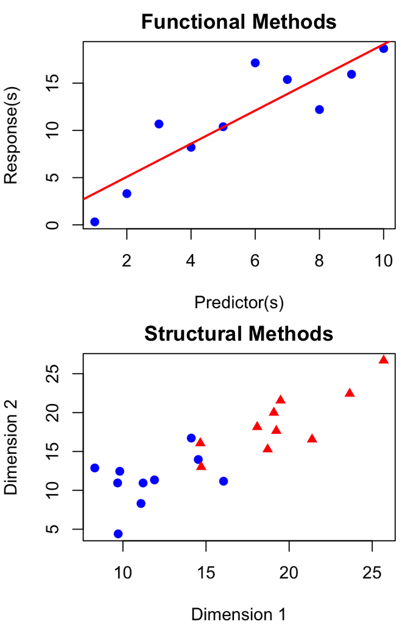

# Structural Methods in Multivariate Analysis

## Two Main Approaches

**Scaling/Ordination Methods**: - Reduce dimensions with new derived variables - Summarize patterns in data - Examples: PCA, CCA

**Dissimilarity-Based Methods**: - Measure dissimilarity between objects - Visualize relationships between objects - Examples: NMDS, Cluster Analysis

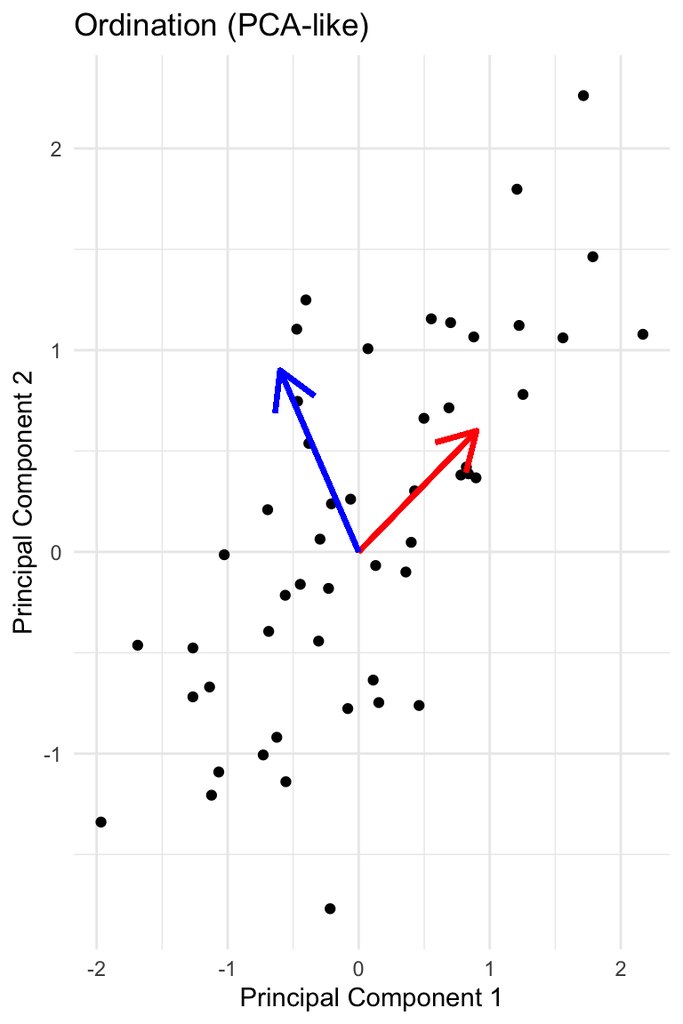

# Eigenvectors, Eigenvalues, and Components

- Goal: derive new variables (principal components) that explain variation in data
- Components are linear combinations of original variables:
  - z<sub>ik</sub> = c<sub>1</sub>y<sub>i1</sub> + c<sub>2</sub>y<sub>i2</sub> + … + c<sub>p</sub>y<sub>ip</sub>
- Properties of derived variables:
  - First component explains most variation
  - Second explains most remaining variation
  - Components are uncorrelated with each other
  - As many components as original variables

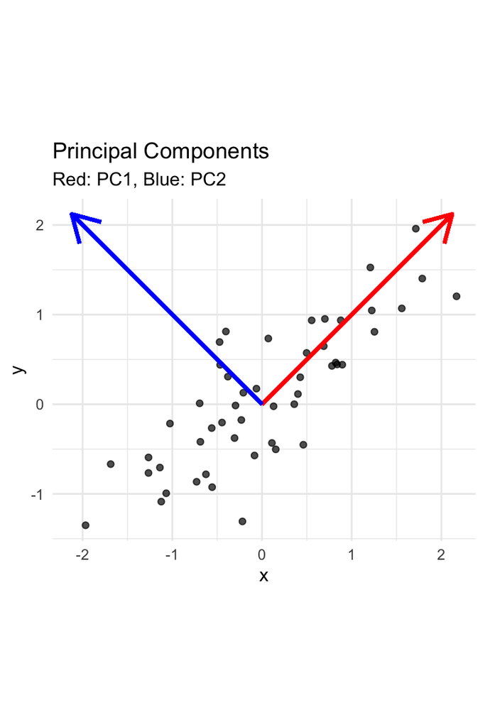

**Key concept**

Eigenvalues (λ) represent the amount of variation explained by each new derived variable, while eigenvectors contain the coefficients showing how original variables contribute to each component.

# Distance and Dissimilarity Measures

- Measure how different objects are in multivariate space
- Common measures:
  - **Euclidean distance**: direct geometric distance
  - **Manhattan distance**: sum of absolute differences
  - **Bray-Curtis**: good for species abundance data
  - **Kulczynski**: for abundance data with zeros
- Used in cluster analysis, MDS, and other techniques
- Create dissimilarity matrices for analysis

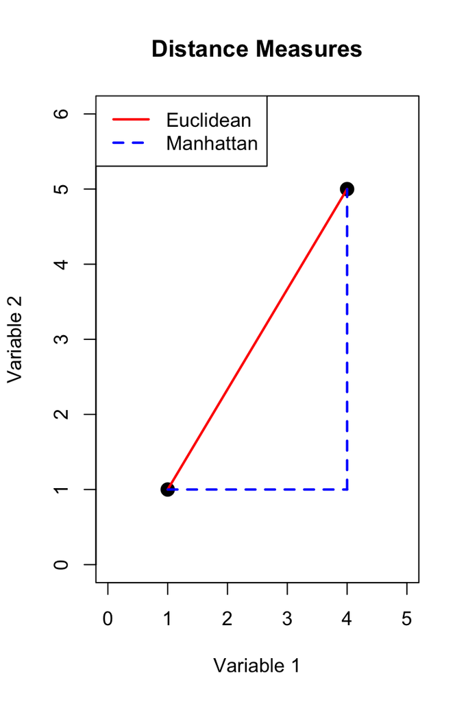

# Data Transformations & Standardization

## Common Approaches

**Transformations**: - Log transformation for skewed data - Root transformations for count data - Fourth-root for species abundance data

**Standardization**: - Centering: subtract mean (mean = 0) - Standardization: divide by SD (SD = 1) - Crucial for variables with different units - May not be appropriate for species data

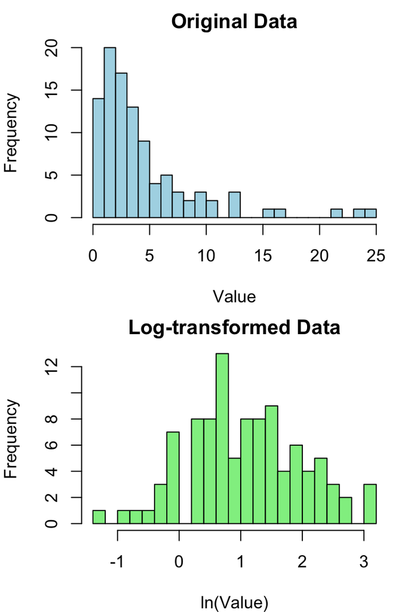

**Why standardize?**

Standardization ensures all variables contribute equally to the analysis regardless of their original units or scales of measurement. Without it, variables with larger values or variances would dominate the results.

# Multivariate Graphics

## Visual Representation Methods

- **SPLOMS/Scatterplot Matrices**: show bivariate relationships
- **Star plots**: display multiple variables per object
- **Chernoff faces**: represent variables as facial features
- **Heatmaps**: visualize data matrices with color
- **Biplots**: show objects and variables together
- **Ordination plots**: visualize relationships in reduced dimensions

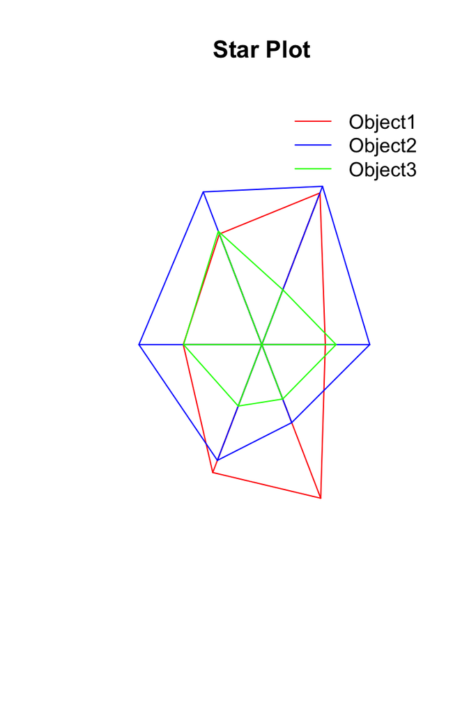

# Screening Multivariate Data

## Key Issues to Check

**Multivariate Outliers**: - Objects with unusual patterns across variables - Detected with Mahalanobis distance (d²) - Test against χ² distribution with p df

**Missing Observations**: - Common approaches: - Deletion: remove affected object or variable - Imputation: estimate missing values - Maximum likelihood methods - Multiple imputation

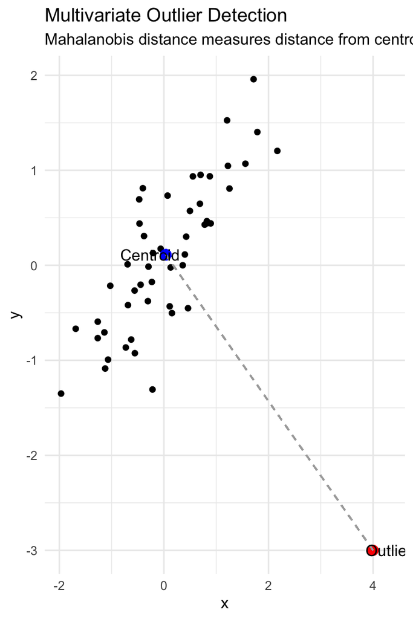

# MANOVA (Multivariate Analysis of Variance)

- Multivariate extension of ANOVA
- Tests for differences in group centroids based on multiple response variables
- Advantages over multiple ANOVAs:
  - Controls family-wise error rate
  - Accounts for correlations between variables
  - More powerful when variables are correlated
- Common test statistics:
  - Wilk’s lambda (λ)
  - Pillai’s trace
  - Hotelling-Lawley trace

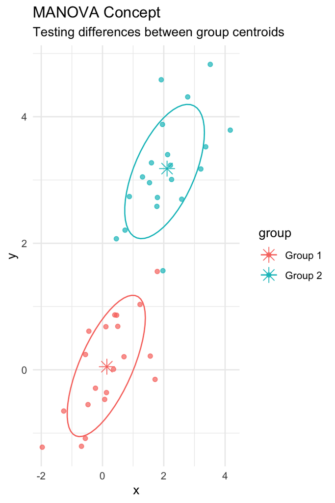

**MANOVA Assumptions**

- Multivariate normality
- Homogeneity of variance-covariance matrices
- No extreme multivariate outliers
- Independence of observations

# Discriminant Function Analysis

- Mathematically similar to MANOVA
- Used for:
  - Testing differences between groups (like MANOVA)
  - Identifying variables that separate groups
  - Classifying observations into groups
- Creates linear combinations (discriminant functions) that maximize between-group differences
- Can assess how well classification performs
- Jackknifed classification provides more realistic success rates

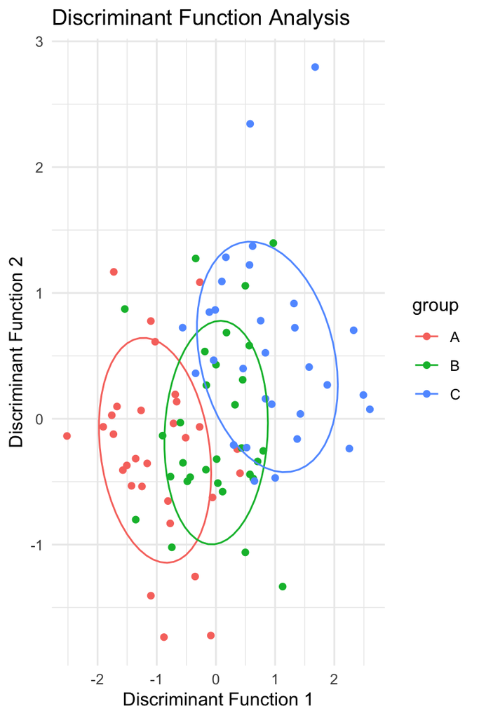

# Summary

## Key Concepts

1. **Multivariate data** requires special techniques to account for correlations between variables
2. **Functional methods** (MANOVA) test hypotheses about group differences
3. **Structural methods** (PCA, NMDS) find patterns in data
4. **Distance measures** quantify similarities between objects
5. **Data standardization** is crucial for variables with different units
6. **Multivariate graphics** help visualize complex relationships

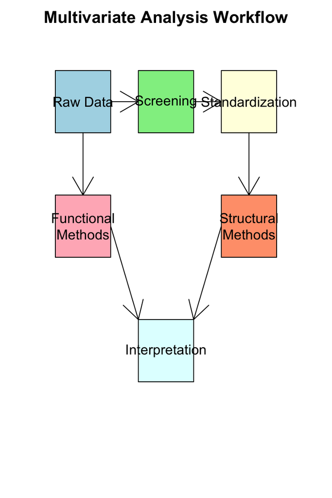

Back to top